# R_assignment

Tae-Chun Park

2024-03-07

### Read data file

```r
url1 <- "https://raw.githubusercontent.com/Taechun/R_assignment/master/fang_et_al_genotypes.txt"
fang_et_al_genotypes <- read.table(url1, header = TRUE)
url2 <- "https://raw.githubusercontent.com/Taechun/R_assignment/master/snp_position.txt"
snp_position <- read.table(url2, header = TRUE, fill = TRUE)
```

## Part 1

#### Inspect structure and dimention of each file

```r
str(fang_et_al_genotypes)
```

```
## 'data.frame':    2782 obs. of  986 variables:
##  $ Sample_ID     : chr  "SL-15" "SL-16" "SL-11" "SL-12" ...
##  $ JG_OTU        : chr  "T-aust-1" "T-aust-2" "T-brav-1" "T-brav-2" ...
##  $ Group         : chr  "TRIPS" "TRIPS" "TRIPS" "TRIPS" ...
##  $ abph1.20      : chr  "?/?" "?/?" "?/?" "?/?" ...
##  $ abph1.22      : chr  "?/?" "?/?" "?/?" "?/?" ...
##  $ ae1.3         : chr  "T/T" "T/T" "T/T" "T/T" ...
##  $ ae1.4         : chr  "G/G" "?/?" "G/G" "G/G" ...
##  $ ae1.5         : chr  "T/T" "T/T" "T/T" "T/T" ...
##  $ an1.4         : chr  "C/C" "C/C" "?/?" "C/C" ...
##  $ ba1.6         : chr  "?/?" "A/G" "G/G" "G/G" ...
##  $ ba1.9         : chr  "G/G" "G/G" "G/G" "G/G" ...
##  $ bt2.5         : chr  "?/?" "?/?" "C/C" "C/C" ...
##  $ bt2.7         : chr  "A/A" "A/A" "A/A" "A/A" ...
##  $ bt2.8         : chr  "?/?" "?/?" "?/?" "?/?" ...
```

[output cut: 86 more lines]

```r
head(fang_et_al_genotypes)
```

```
##   Sample_ID   JG_OTU Group abph1.20 abph1.22 ae1.3 ae1.4 ae1.5 an1.4 ba1.6
## 1     SL-15 T-aust-1 TRIPS      ?/?      ?/?   T/T   G/G   T/T   C/C   ?/?
## 2     SL-16 T-aust-2 TRIPS      ?/?      ?/?   T/T   ?/?   T/T   C/C   A/G
## 3     SL-11 T-brav-1 TRIPS      ?/?      ?/?   T/T   G/G   T/T   ?/?   G/G
## 4     SL-12 T-brav-2 TRIPS      ?/?      ?/?   T/T   G/G   T/T   C/C   G/G
## 5     SL-18   T-cund TRIPS      ?/?      ?/?   T/T   G/G   T/T   C/C   ?/?
## 6      SL-2 T-dact-1 TRIPS      ?/?      ?/?   T/T   G/G   T/T   C/C   A/G
##   ba1.9 bt2.5 bt2.7 bt2.8 Fea2.1 Fea2.5 id1.3 lg2.11 lg2.2 pbf1.1 pbf1.2 pbf1.3
## 1   G/G   ?/?   A/A   ?/?    C/C    A/A   T/T    C/C   A/A    ?/?    ?/?    ?/?
## 2   G/G   ?/?   A/A   ?/?    C/C    A/A   T/T    C/C   A/A    T/T    ?/?    ?/?
## 3   G/G   C/C   A/A   ?/?    ?/?    A/A   T/T    C/C   A/A    T/T    ?/?    ?/?
## 4   G/G   C/C   A/A   ?/?    ?/?    A/A   T/T    C/C   A/A    T/T    ?/?    ?/?
## 5   G/G   ?/?   A/A   ?/?    C/C    A/A   T/T    C/C   A/A    T/T    ?/?    ?/?
## 6   G/G   ?/?   A/A   ?/?    C/C    A/A   T/T    C/C   A/A    T/T    ?/?    ?/?
##   pbf1.5 pbf1.6 pbf1.7 pbf1.8 PZA00003.11 PZA00004.2 PZA00005.8 PZA00005.9
```

[output cut: 1021 more lines]

```r
dim(fang_et_al_genotypes)
```

```
## [1] 2782  986
```

```r
str(snp_position)
```

```
## 'data.frame':    1017 obs. of  15 variables:
##  $ SNP_ID              : chr  "abph1.20" "abph1.22" "ae1.3" "ae1.4" ...
##  $ cdv_marker_id       : chr  "5976" "5978" "6605" "6606" ...
##  $ Chromosome          : chr  "2" "2" "5" "5" ...
##  $ Position            : chr  "27403404" "27403892" "167889790" "167889682" ...
##  $ alt_pos             : chr  "abph1" "abph1" "ae1" "ae1" ...
##  $ mult_positions      : chr  "AB042260" "AB042260" "ae1" "ae1" ...
##  $ amplicon            : chr  "abph1" "abph1" "ae1" "ae1" ...
##  $ cdv_map_feature.name: chr  "candidate" "candidate" "candidate" "candidate" ...
##  $ gene                : chr  "8393" "8394" "8395" "8396" ...
##  $ candidate.random    : chr  "10474" "10475" "10477" "10478" ...
##  $ Genaissance_daa_id  : chr  "1" "0" "1" "0" ...
##  $ Sequenom_daa_id     : chr  "1" "0" "1" "0" ...
##  $ count_amplicons     : chr  "1" "0" "1" "0" ...
##  $ count_cmf           : chr  "" "" "" "" ...
##  $ count_gene          : chr  "" "" "" "" ...
```

```r
head(snp_position)
```

```
##     SNP_ID cdv_marker_id Chromosome  Position alt_pos mult_positions amplicon
## 1 abph1.20          5976          2  27403404   abph1       AB042260    abph1
## 2 abph1.22          5978          2  27403892   abph1       AB042260    abph1
## 3    ae1.3          6605          5 167889790     ae1            ae1      ae1
## 4    ae1.4          6606          5 167889682     ae1            ae1      ae1
## 5    ae1.5          6607          5 167889821     ae1            ae1      ae1
## 6    an1.4          5982          1 240498509     an1            an1      an1
##   cdv_map_feature.name gene candidate.random Genaissance_daa_id Sequenom_daa_id
## 1            candidate 8393            10474                  1               1
## 2            candidate 8394            10475                  0               0
## 3            candidate 8395            10477                  1               1
## 4            candidate 8396            10478                  0               0
## 5            candidate 8397            10479                  0               0
## 6            candidate 8398            10481                  1               1
##   count_amplicons count_cmf count_gene
## 1               1
## 2               0
## 3               1
## 4               0
## 5               0
## 6               1
```

```r
dim(snp_position)
```

```
## [1] 1017   15
```

```r
summary(snp_position)
```

```
##     SNP_ID          cdv_marker_id       Chromosome          Position
##  Length:1017        Length:1017        Length:1017        Length:1017
##  Class :character   Class :character   Class :character   Class :character
##  Mode  :character   Mode  :character   Mode  :character   Mode  :character
##    alt_pos          mult_positions       amplicon         cdv_map_feature.name
##  Length:1017        Length:1017        Length:1017        Length:1017
##  Class :character   Class :character   Class :character   Class :character
##  Mode  :character   Mode  :character   Mode  :character   Mode  :character
##      gene           candidate.random   Genaissance_daa_id Sequenom_daa_id
##  Length:1017        Length:1017        Length:1017        Length:1017
##  Class :character   Class :character   Class :character   Class :character
##  Mode  :character   Mode  :character   Mode  :character   Mode  :character
##  count_amplicons     count_cmf          count_gene
##  Length:1017        Length:1017        Length:1017
##  Class :character   Class :character   Class :character
##  Mode  :character   Mode  :character   Mode  :character
```

```r
file.info("fang_et_al_genotypes.txt")$size
```

```
## [1] 11051939
```

```r
file.info("snp_position.txt")$size
```

```
## [1] 82763
```

With the commands above, ‘fang_el_al_genotypes’ has 2782 observations, and 986 variables with commends of str and dim and ‘snp_position’ has 1017 observations, and 15 variations. and the file size of fang_el_al is 11051939 and 82763 for snp_position. And Both files are included characters in each column.

### Join the files

As our assignment instructor, I wanted to extract “SNP_ID”, “Chromosome” and “Position” from SNP_position file

```r
snp_data <- snp_position[,c(1,3,4)]
```

After that, I wanted to extract two groups (maize and teosinte) from fang_et_al_genotypes.

```r
maize <- fang_et_al_genotypes[fang_et_al_genotypes$Group %in% c("ZMMIL", "ZMMLR", "ZMMMR"),]
rownames(maize) <- NULL
teosinte <- fang_et_al_genotypes[fang_et_al_genotypes$Group %in% c("ZMPBA", "ZMPIL", "ZMPJA"),]
rownames(teosinte) <- NULL
```

Then, I don’t need the first three columns of each file.

```r
maize_cut <- maize[,c(4:ncol(maize))]
teosinte_cut <- teosinte[,c(4:ncol(teosinte))]
```

Now, I need to transpose those files. To do that, I need to change those files to data frame.

```r
trans_maize <- t(maize_cut)
trans_teosinte <- t(teosinte_cut)
```

Last step, I need to combine those two files

```r
trans_maize <- as.data.frame(trans_maize)
trans_maize <- data.frame("SNP_ID"=rownames(trans_maize), trans_maize)
trans_maize$SNP_ID <- row.names(trans_maize)
merged_maize <- merge(snp_data, trans_maize, by = "SNP_ID")
trans_teosinte <- as.data.frame(trans_teosinte)
trans_teosinte <- data.frame("SNP_ID"=rownames(trans_teosinte), trans_teosinte)
trans_teosinte$SNP_ID <- row.names(trans_teosinte)
merged_teosinte <- merge(snp_data, trans_teosinte, by = "SNP_ID")
```

Now I am ready to do the assignment.

-10 files (1 for each chromosome) with SNPs ordered based on increasing position values and with missing data encoded by this symbol: ?

```r
chr_1_data <- merged_maize[merged_maize$Chromosome == 1, ]
chr_1_sorted <- chr_1_data[order(as.numeric(chr_1_data$Position)), ]
missing_rows <- subset(chr_1_sorted, apply(chr_1_sorted[, 4:49], 1, function(x) any(x == "?/?")))
write.table(missing_rows, file = "missing_rows.txt", sep = "\t", quote = FALSE, row.names = TRUE)
```

It takes too long time to repeat chr1 to chr10. So, using a loop to do the operation for chr1 to 10.

```r
for (chromosome in 1:10) {
  chr_data <- merged_maize[merged_maize$Chromosome == chromosome, ]
  chr_sorted <- chr_data[order(as.numeric(gsub("[^0-9]", "", chr_data$Position))), ]
  missing_rows <- subset(chr_sorted, apply(chr_sorted[, 4:49], 1, function(x) any(x == "?/?")))
   filename <- paste0("maize_?_rows_chr", chromosome, ".txt")
  write.table(missing_rows, file = filename, sep = "\t", quote = FALSE, row.names = TRUE)
}
```

10 files (1 for each chromosome) with SNPs ordered based on decreasing position values and with missing data encoded by this symbol: -

```r
for (chromosome in 1:10) {
  chr_data <- merged_maize[merged_maize$Chromosome == chromosome, ]
  chr_sorted <- chr_data[order(-as.numeric(gsub("[^0-9]", "", chr_data$Position))), ]
  missing_rows <- subset(chr_sorted, apply(chr_sorted[, 4:49], 1, function(x) any(x == "-")))
   filename <- paste0("maize_-_rows_chr", chromosome, ".txt")
  write.table(missing_rows, file = filename, sep = "\t", quote = FALSE, row.names = TRUE)
}
```

10 files (1 for each chromosome) with SNPs ordered based on increasing position values and with missing data encoded by this symbol: ?

```r
for (chromosome in 1:10) {
  chr_data <- merged_teosinte[merged_teosinte$Chromosome == chromosome, ]
  chr_sorted <- chr_data[order(as.numeric(gsub("[^0-9]", "", chr_data$Position))), ]
  missing_rows <- subset(chr_sorted, apply(chr_sorted[, 4:49], 1, function(x) any(x == "?/?")))
   filename <- paste0("teosinte_?_rows_chr", chromosome, ".txt")
  write.table(missing_rows, file = filename, sep = "\t", quote = FALSE, row.names = TRUE)
}
```

10 files (1 for each chromosome) with SNPs ordered based on decreasing position values and with missing data encoded by this symbol: -

```r
for (chromosome in 1:10) {
  chr_data <- merged_teosinte[merged_teosinte$Chromosome == chromosome, ]
  chr_sorted <- chr_data[order(-as.numeric(gsub("[^0-9]", "", chr_data$Position))), ]
  missing_rows <- subset(chr_sorted, apply(chr_sorted[, 4:49], 1, function(x) any(x == "-")))
   filename <- paste0("teosinte_-_rows_chr", chromosome, ".txt")
  write.table(missing_rows, file = filename, sep = "\t", quote = FALSE, row.names = TRUE)
}
```

## Part 2

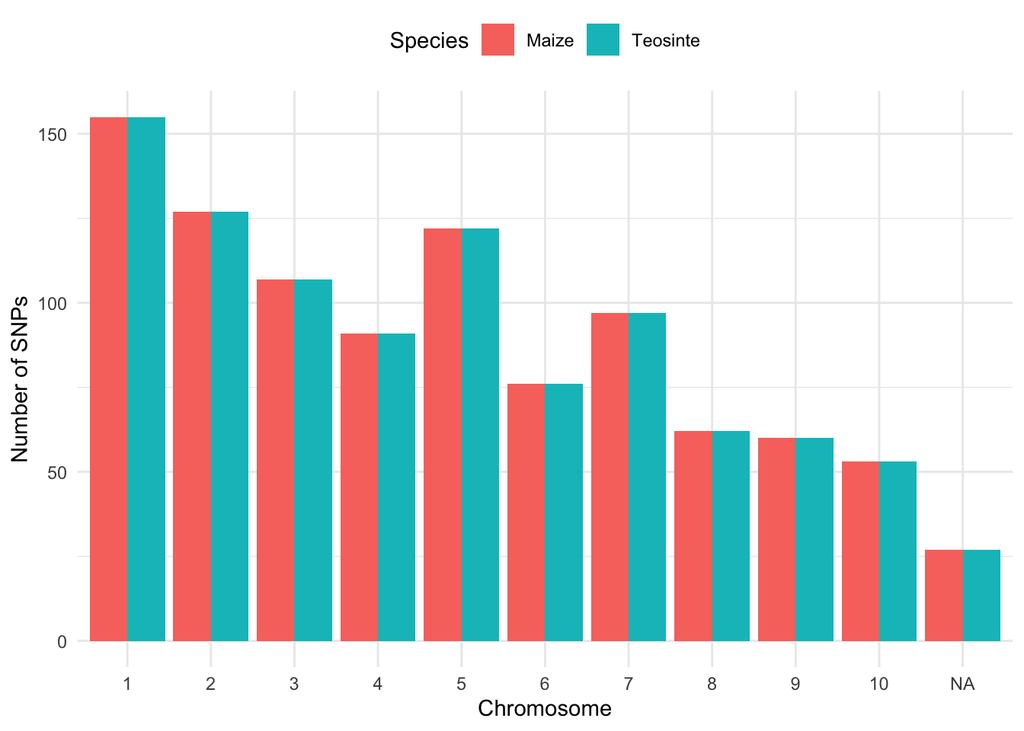

```r
library(ggplot2)
maize_counts <- table(merged_maize$Chromosome)
teosinte_counts <- table(merged_teosinte$Chromosome)
df <- data.frame(
  Chromosome = as.numeric(names(maize_counts)),
  Maize = as.numeric(maize_counts),
  Teosinte = as.numeric(teosinte_counts)
)
df_long <- tidyr::pivot_longer(df, cols = c(Maize, Teosinte),
                               names_to = "Species", values_to = "Count")
ggplot(df_long, aes(x = factor(Chromosome), y = Count, fill = Species)) +
  geom_bar(stat = "identity", position = "dodge") +
  labs(x = "Chromosome", y = "Number of SNPs", fill = "Species") +
  theme_minimal() +
  theme(legend.position = "top")
```

*The distribution of SNPs showed the highest tendency on chr1 and the lowest on chr10. However, chr5 exhibited a distribution similar to chr2, and chr7 showed a distribution similar to chr4. Additionally, the distribution of SNPs was similar across each chromosome in the two species.

#### Missing data and amount of heterozygosity

*Let’s make a new column called zygous with genotypic data

```r
library(tidyverse)
cmaize <- maize %>% select(-JG_OTU) %>% pivot_longer(-Sample_ID:-Group)
c_cmaize <- cmaize %>%
  mutate(zygous = ifelse(value %in% c("A/A", "T/T", "G/G", "C/C"), "Homozygous",
                         ifelse(value == "?/?", "Missing", "Heterozygous")))
```

*Count the each value

```r
count_heterozygous <- sum(c_cmaize$zygous == "Heterozygous")
print(count_heterozygous)
```

```
## [1] 207813
```

```r
count_homozygous <- sum(c_cmaize$zygous == "Homozygous")
print(count_homozygous)
```

```
## [1] 1263501
```

```r
count_missing <- sum(c_cmaize$zygous == "Missing")
print(count_missing)
```

```
## [1] 74945
```

*Visualization by each sample

```r
count_data <- c_cmaize %>%
  group_by(Sample_ID, zygous) %>%
  summarise(count = n())
```

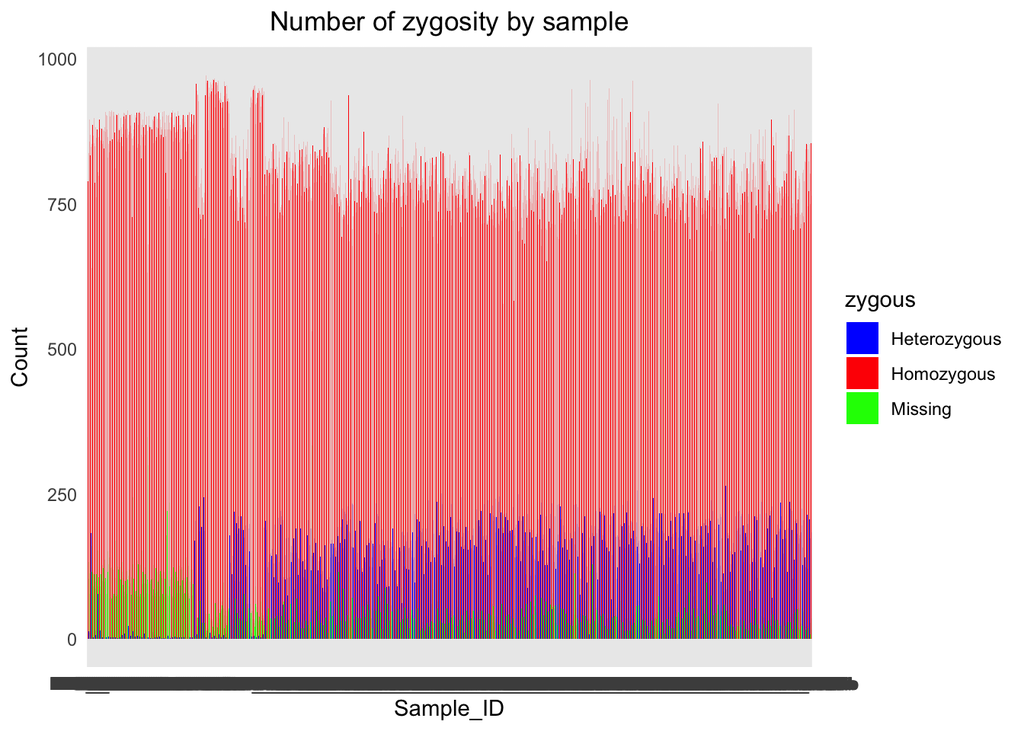

```r
ggplot(count_data, aes(x = Sample_ID, y = count, fill = zygous)) +
  geom_bar(stat = "identity", position = "dodge") +
  labs(title = "Number of zygosity by sample", x = "Sample_ID", y = "Count") +
  scale_fill_manual(values = c("Heterozygous" = "blue", "Homozygous" = "red", "Missing" = "green")) +
  theme_minimal() +
  theme(plot.title = element_text(hjust = 0.5))
```

*Visualization by each group

```r
count_data_group <- c_cmaize %>%
  group_by(Group, zygous) %>%
  summarise(count = n())
```

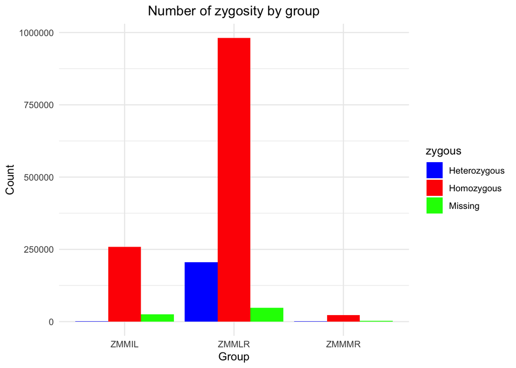

```r
ggplot(count_data_group, aes(x = Group, y = count, fill = zygous)) +
  geom_bar(stat = "identity", position = "dodge") +
  labs(title = "Number of zygosity by group", x = "Group", y = "Count") +
  scale_fill_manual(values = c("Heterozygous" = "blue", "Homozygous" = "red", "Missing" = "green")) +
  theme_minimal() +
  theme(plot.title = element_text(hjust = 0.5))
```

### Your own visualization

*Make a figure to see the value distribution by group

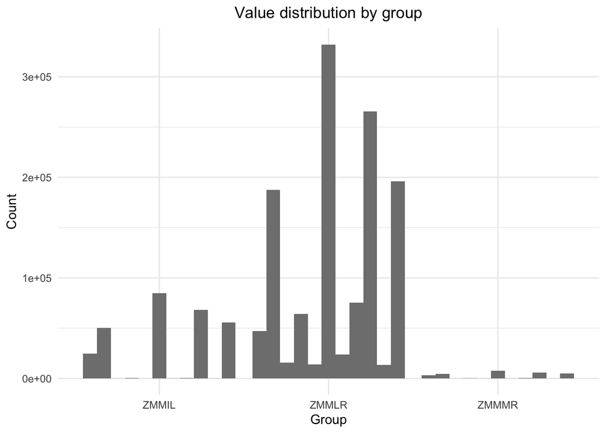

```r
count_zygous_geno <- cmaize %>%
  group_by(Group, value) %>%
  summarise(count = n(), .groups = "drop")
ggplot(count_zygous_geno, aes(x = Group, y = count, fill = value)) +
  geom_bar(stat = "identity", position = "dodge") +
  labs(title = "Value distribution by group", x = "Group", y = "Count") +
  scale_fill_manual(values = c("Heterozygous" = "blue", "Homozygous" = "red", "Missing" = "green")) +
  theme_minimal() +
  theme(plot.title = element_text(hjust = 0.5))
```